# Brazil’s Government IT spending by Vitor Bellini

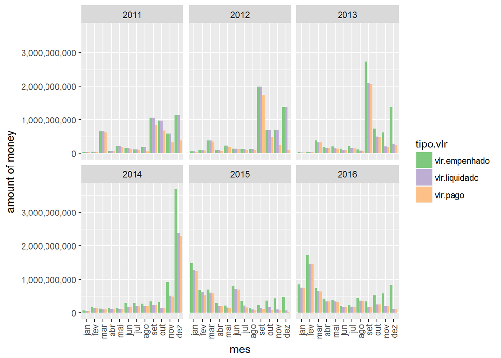

By month and year, the distribution does not seems to have a pattern. The amounts of reserved, charged and payed vary together.

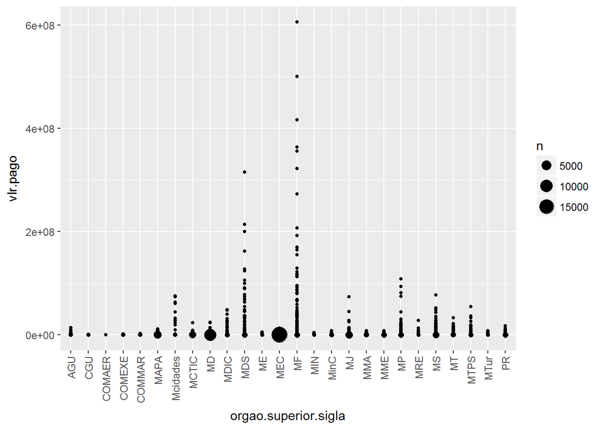

MEC and MD are the Department with higher number of contracts, but with low values. MF and MDS has low contract numbers with high values.

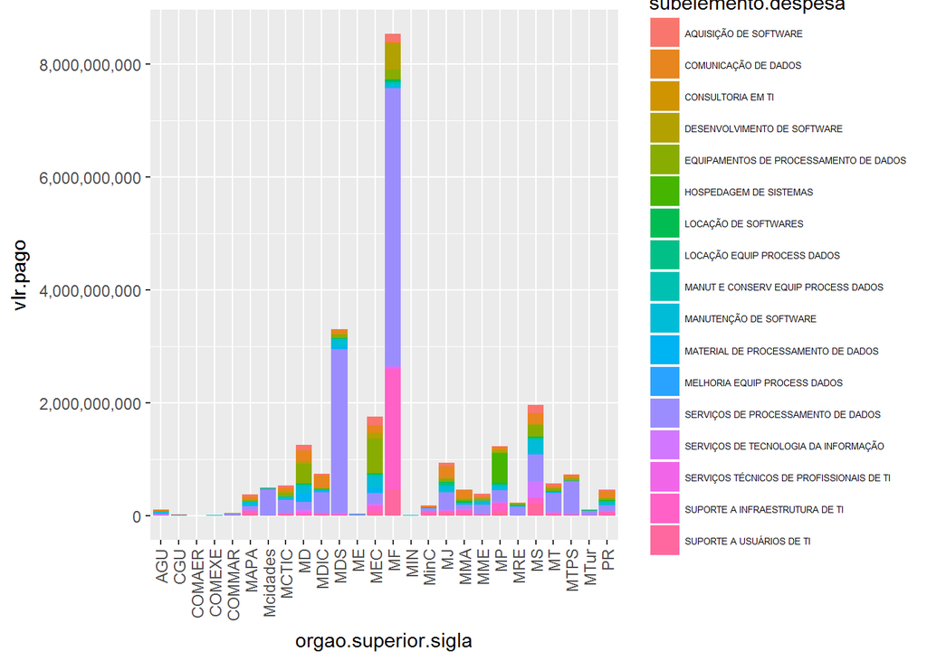

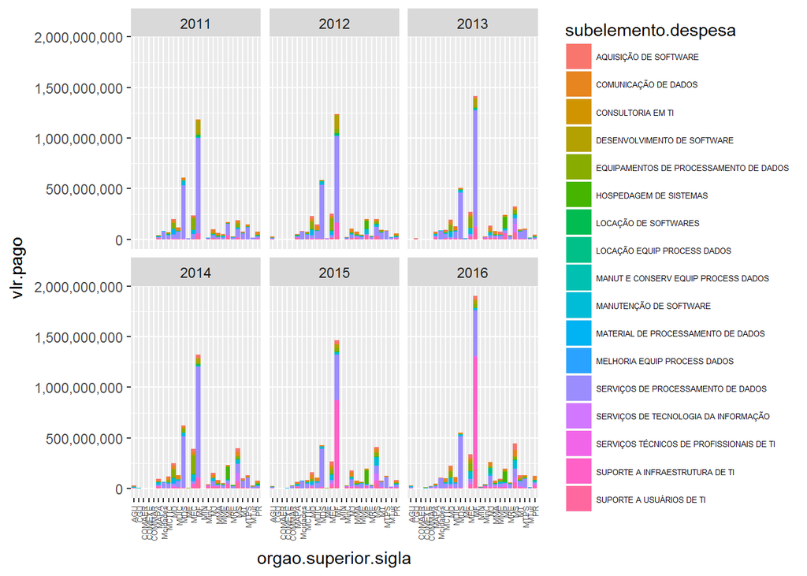

This graph shows how the Departments allocate their IT budget. The shift from “data processing services” to “IT infrastructure support” identified on the previous session was made by the Treasury on 2015.

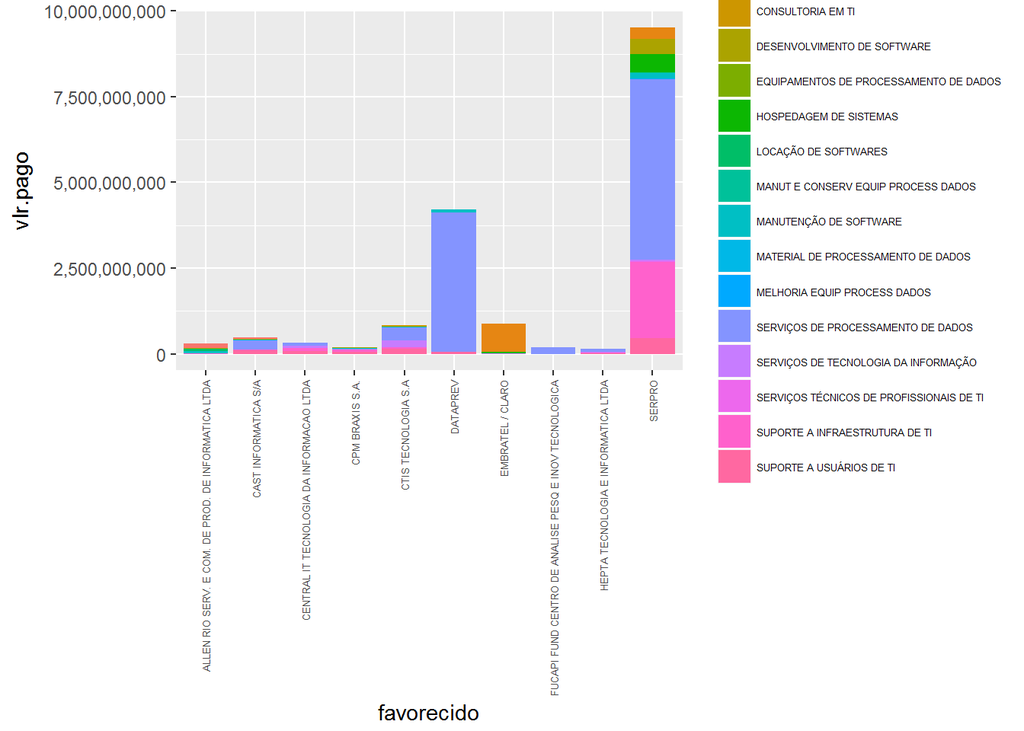

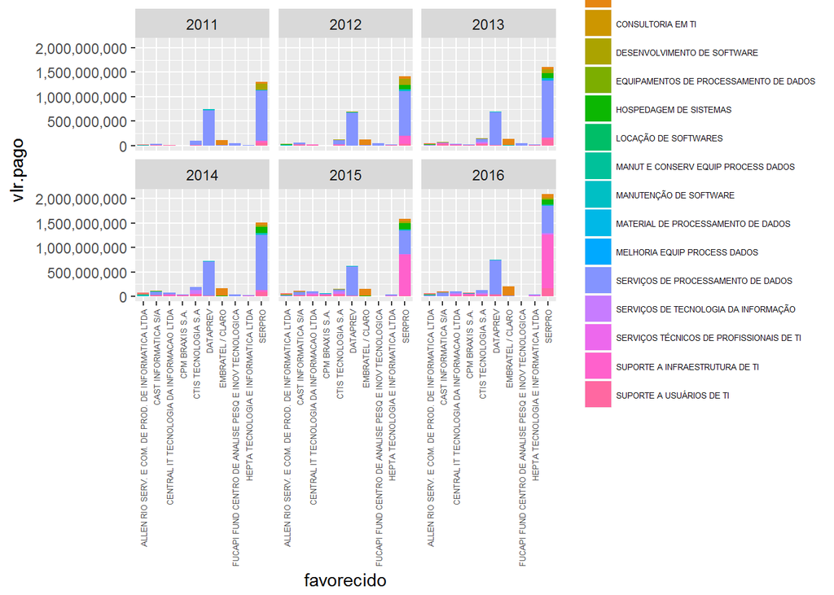

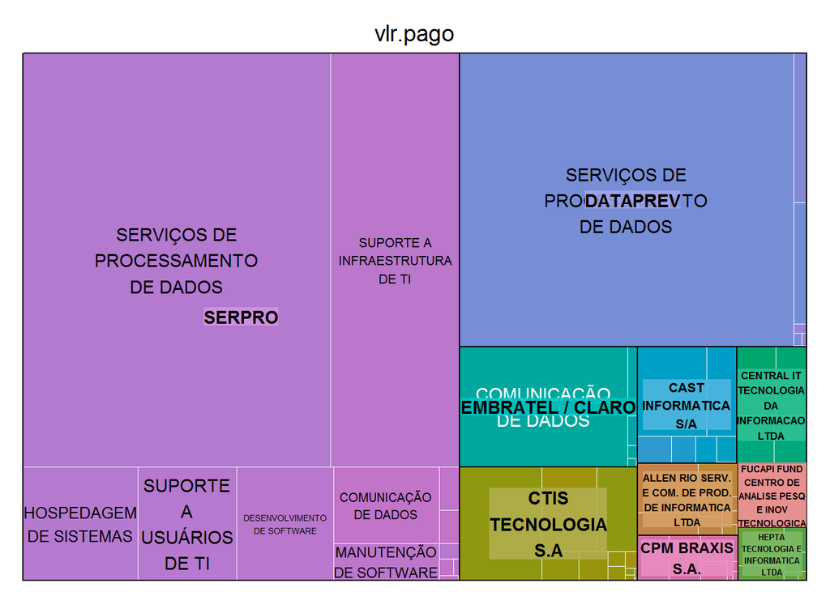

By the top 10 companies,the two main that offers “data processing services” and “IT infrastructure support” are Serpro and Dataprev. The hypothesis on the previous session that high “IT infrastructure support” could be due to on-premises data centers can be rejected. Serpro is the company that most sold this service and it offers Infrastructure as a Service on the cloud.

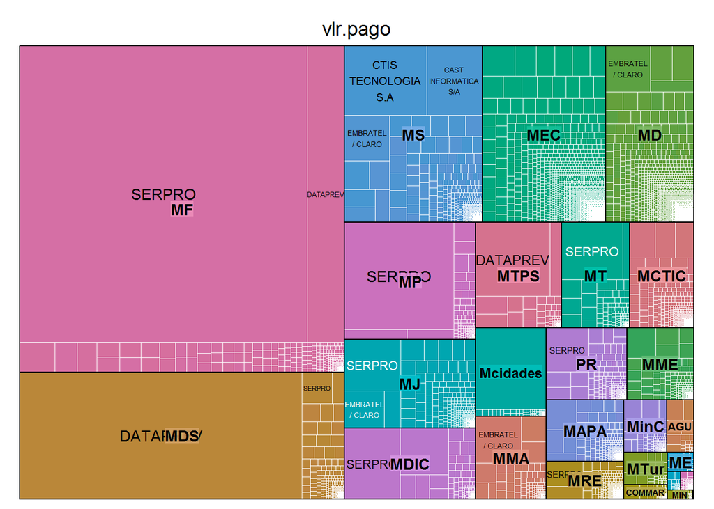

Treasury and MDS, the top IT spenders, have big contracts with Serpro and Dataprev. MS, MEC and MD have higher number of providers with lower amount.

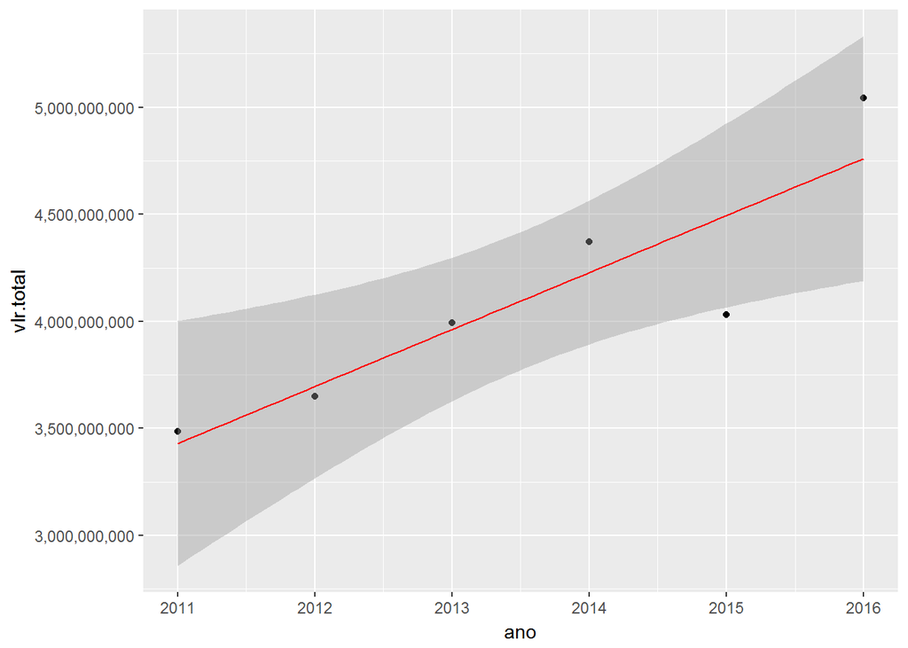

```
##
## Calls:
## m1: lm(formula = vlr.total ~ ano, data = Gov_spents)
##
## ===========================================
##   (Intercept)          -531906361329.956*
##                        (136880111006.792)
##   ano                      266203934.943*
##                            (67981158.068)
## -------------------------------------------
##   R-squared                        0.793
##   adj. R-squared                   0.741
##   sigma                    284385587.564
##   F                               15.334
##   p                                0.017
##   Log-likelihood                -124.092
##   Deviance        323500649656928192.000
##   AIC                            254.185
##   BIC                            253.560
##   N                                6
## ===========================================
```

The variable year on the linear model explain 79.3% of the yearly IT spent.

```
##          fit        lwr        upr
## 1 5026975450 3948202470 6105748430
```

By the model, on 2017 it’s predicted that the Brazil’s Federal Government will spent 5.03 Billions of Reais on IT.

# Multivariate Analysis

### Talk about some of the relationships you observed in this part of the investigation. Were there features that strengthened each other in terms of looking at your feature(s) of interest?

The high amounts spent by the Department occur on specific contracts. Most contracts have lower values.

The higher spent on government is to “data processing services”, provided mainly by Serpro and Dataprev. Serpro is the main provider of the Treasury while Dataprev is the main provider of MDS.

### Were there any interesting or surprising interactions between features?

The shift of amount spent from item “data processing services” to “IT infrastructure support” looks like an strategic shift. But by the plots we could see that this shift was under the same company (Serpro), indicating more a contractual adjustment than actually an strategy change.

### OPTIONAL: Did you create any models with your dataset?

I created a linear model to predict IT spents by year. This model has just the year as predictor and it explains 79.3% of the IT Federal Government spent by year.

# Final Plots and Summary

### Plot First

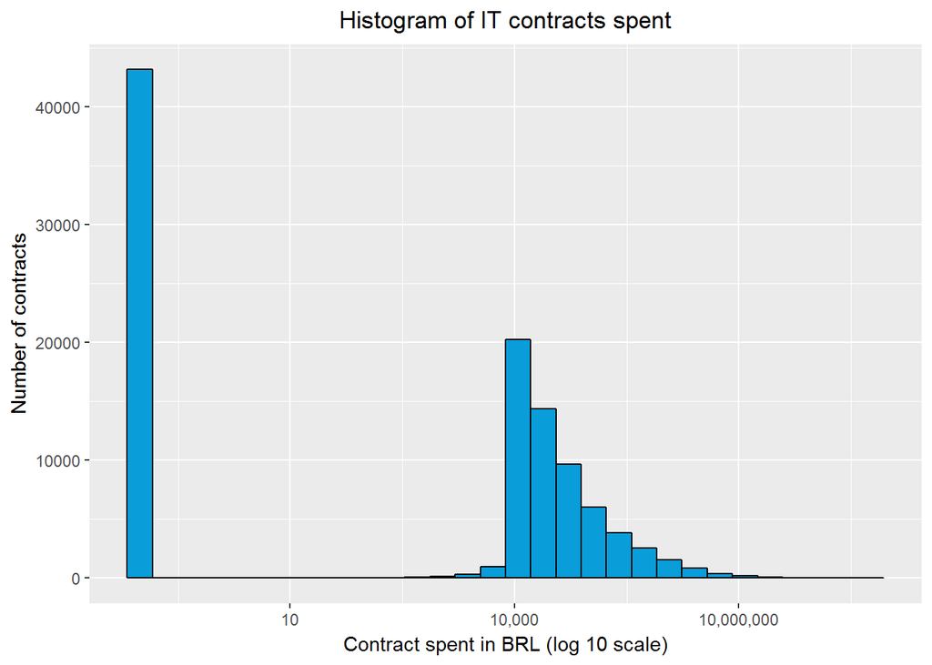

### Description First

The objective of this plot is to identify the values spent by contracts, what were more frequent and how they are distributed.

The gap between 0 and 8,000 is due to a slice made on the original dataset. Public binding in Brazil starts at 8,000 so I discarded the contracts that had lower than 8,000 reserved because of lack of information on what happened on these cases.

### Plot Two

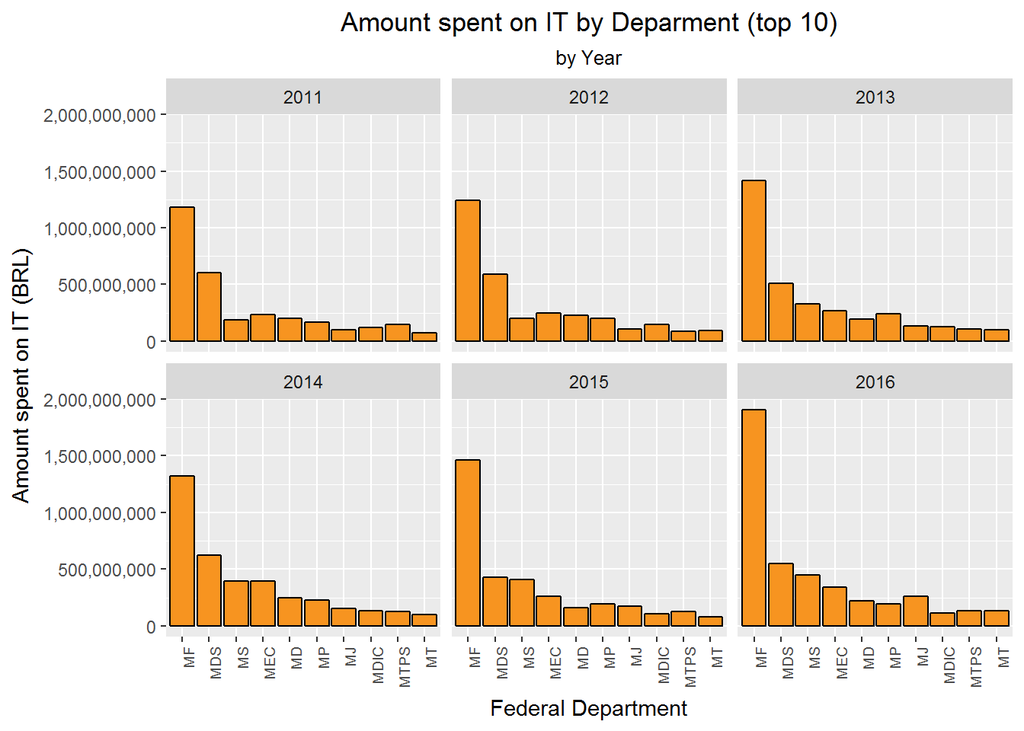

### Description Two

The bar plot does a good job comparing categorical vairables, such as Federal Departments spents. In this plot is possible to identify the amounts spent and how they differ from the other Departments.

Treasury (MF) is the Department with higher IT spent along the years 2011 to 2016, and Ministry of Social Development (MDS) the second. Together they represent almost 50% of federal IT expenses, with 35% to Treasury and 13% to MDS.

The amount spent by the Treasury is more than twice of the Ministry of Social Development and it has growing through the years. While the Treasury is responsible to collecting income tax declaration, an exclusive on-line service, the MDS is the Department responsible for social security and retirement.

### Plot Three

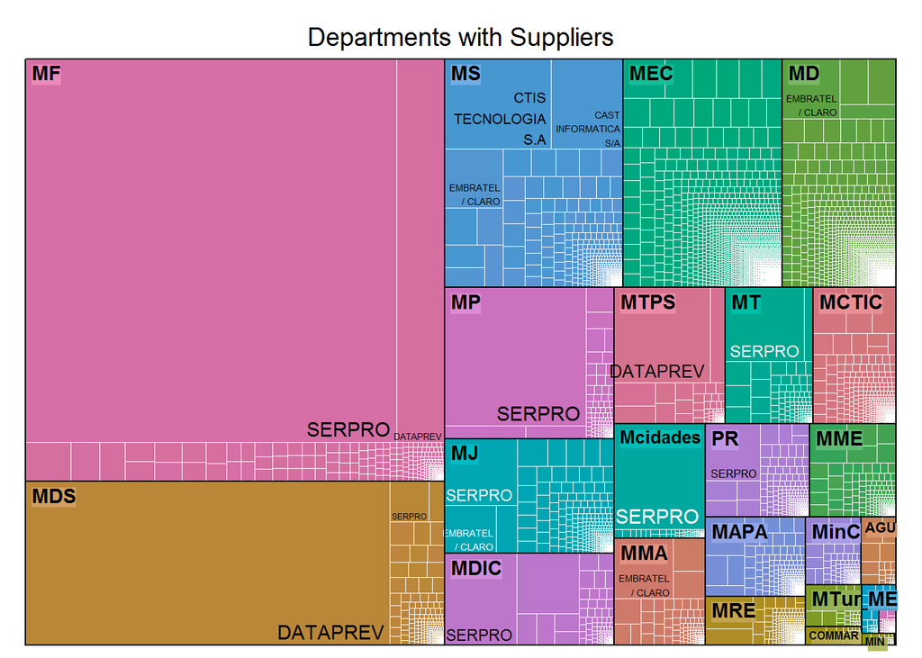

### Description Three

This treemap plot does a great job comparing the amount of IT spent by Department and by Suppliers. It’s easy to identify the highest spenders and the distribution of the Suppliers within the Departments.

The main IT suppliers of the Federal Government are Serpro and Dataprev, the two brazilian Public IT companies, an overall of 56% spent, with 39% to Serpro and 17% to Dataprev. Serpro is the main supplier of the Treasury (80% of it’s Supplier spent) and Dataprev of the Ministry of Social Development (87% of it’s Supplier spent). MP, MT and MDIC have high Serpro contracts wile MTPS Dataprev. Ministry of Education (MEC) and Ministry of Defense (MD) have high number of suppliers with lower contract values. It’s even more unusual the Ministry of Cities distribution, almost 93% of it’s IT budget is spent with Serpro.

Linking with the plot two, Serpro is the supplier responsible of the income tax declaration system, and Dataprev, the retirement and social security system.

# Reflection

The Brazil’s Federal Government IT spent dataset has information about almost 105,000 public contracts between the years 2011 and 2016. My purpose was to understand how the IT budget was beeing allocated, what are the main players (public and privated) and what kind of services/products are bought. I started exploring the individual variables by using histogram and bar charts and then moved to bi and multi variated analysis by adding the costs of the contracts and combining multiple variables on the plots.

I’ve found that the Treasury and the Ministry of Social Development are the main IT spenders and that Serpro and Dataprev, public companies, are the main suppliers. The IT budget increased along the years and there is a 36% gap between reserved/planned and spent amounts. The two top contracted items were “data processing services” and “IT infrastructure support”. On 2015 the amount spent on “data processing services” decreased, while “IT infrastructure support” increased. It appeared an strategy shift, but it occured within the same supplier, Serpro, indicating more a contractual adjustment then actually a change on the way the service is provided.

The high correlation between number of Management Units and number of contracts could be an opportunity to the Departments conduct coletive purchases aiming standarization, quality and lower prices.

The dataset used for this analysis was provided by SIGA, a Senate system to monitor public spent. It had several contracts with zero and below 8,000 (minimal public bidding) values. Because of that, to reduce biased conclusions, I’ve decided to discard 355,777 out of 460,0228 registries. It wasn’t clear what happened with these cases but certainly this action moved away what really happened from the partial data that I had available to analysis. Also, since IT acquisitions are relatively new and change very quick, it is possible that some contracts weren’t precisely classified. Lastly, the inflation wasn’t considered on the analysis, but usually it stands around 6% a year in Brazil.

For further works on this subject, I think that efforts on closing the gap between the planned budget and the payed amount could help to develop a more lean and concise government. Also, evaluating the return on IT investments could help to better allocate IT resources.

# References

- [Bidding/Public purchases law](http://www.planalto.gov.br/ccivil_03/leis/L8666cons.htm)
- [Udacity Project Example](https://s3.amazonaws.com/content.udacity-data.com/courses/ud651/diamondsExample_2016-05.html)
- [IT spent monitor - SIGA](https://www12.senado.leg.br/orcamento/sigabrasil)
- [ggplot2 Examples](http://r-statistics.co/Top50-Ggplot2-Visualizations-MasterList-R-Code.html)
- [Treemap plot](http://www.r-graph-gallery.com/portfolio/treemap/)
- [Treemap plot documentation](https://www.rdocumentation.org/packages/treemap/versions/2.4-2/topics/treemap)
- [Treemap plot labels alignment](https://stackoverflow.com/questions/18128370/how-do-i-change-the-position-of-labels-in-the-r-treemap)
- [R styleguide](http://adv-r.had.co.nz/Style.html)
- [Google’s R styleguide](http://google.github.io/styleguide/Rguide.xml#linelength)